# ShapleyForest on Real Data: World Development Indicators

Author

Timothy Shen

Published

July 22, 2026

# 1 Introduction

This vignette demonstrates the full Shapley Forest (SF) workflow on the **World Development Indicators (WDI)** dataset from the World Bank. Unlike the gene-expression panels used in the other vignettes, this is a **non-biological, genuinely high-dimensional ($p > n$) tabular dataset** whose features are intuitive to a general audience — GDP per capita, literacy rate, CO₂ emissions, urban population share, and hundreds of other national statistics. The task is to predict a country’s **life expectancy at birth** from its development profile.

The dataset is deliberately in the same regime as genomics: **501 indicators for only 181 countries**. Many indicators are strongly correlated (a country rich on one economic axis tends to be rich on many), so — exactly as with co-expressed genes — a model can “explain” the outcome with almost any one of a redundant block as a stand-in for the others. SF’s screening + shadow-stability machinery exists to cut through blocks like this.

The vignette is separated in four stages:

1. Data loading and summary
2. WGCNA
3. Single SF run and output for exploration purposes
4. Nested cross-validation comparing all six SF variants with joint hyperparameter tuning

# 2 Data

We first load the data (included in the package).

```r
if (!require("devtools", quietly = TRUE))
    install.packages("devtools")
library(devtools)
devtools::install_github("timothyzshen/shapleyforest")

library(shapleyforest)
library(WGCNA)
```

```r
data(wdi)

wdi_X      <- as.data.frame(wdi$X)
wdi_y      <- wdi$y
wdi_labels <- wdi$labels   # indicator code -> human-readable name

cat("Countries :", nrow(wdi_X), "\n")
```

```
Countries : 181
```

```r
cat("Indicators:", ncol(wdi_X), "\n")
```

```
Indicators: 501
```

```r
cat("Outcome   : life expectancy at birth,",
    paste(round(range(wdi_y), 1), collapse = " - "), "years\n")
```

```
Outcome   : life expectancy at birth, 50.6 - 85.5 years
```

We have a $181 \times 501$ matrix — more features than observations — where the outcome is a continuous quantity (years of life expectancy). This is a regression problem, so throughout we score models by **out-of-sample $R^2$** (and RMSE in years) rather than the AUC used in the classification vignettes.

## 2.1 Feature correlation structure

Before fitting anything it is worth seeing *why* this is a hard selection problem: most of these indicators move together. Rather than an unreadable $501 \times 501$ heatmap, we summarise the redundancy directly — the distribution of absolute pairwise **Spearman** (rank) correlations among all indicators. We use Spearman rather than Pearson because development indicators are heavily skewed (GDP, population, and land area span orders of magnitude) and often related monotonically but non-linearly; a rank correlation captures those associations that raw Pearson understates.

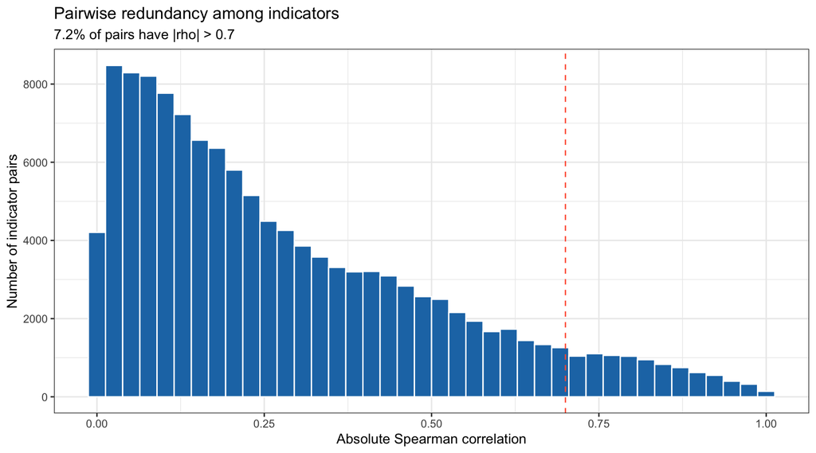

Distribution of absolute pairwise Spearman correlations among the 501 indicators. The right tail marks blocks of mutually-redundant features — exactly the structure SF is designed to navigate.

```r
library(ggplot2)

cor_mat <- cor(wdi_X, method = "spearman")
off_diag <- abs(cor_mat[upper.tri(cor_mat)])

ggplot(data.frame(r = off_diag), aes(x = r)) +
  geom_histogram(bins = 40, fill = "#1F77B4", colour = "white") +
  geom_vline(xintercept = 0.7, linetype = "dashed", colour = "tomato") +
  labs(title    = "Pairwise redundancy among indicators",
       subtitle = sprintf("%.1f%% of pairs have |rho| > 0.7",
                          100 * mean(off_diag > 0.7)),
       x = "Absolute Spearman correlation", y = "Number of indicator pairs") +
  theme_bw()
```

# 3 WGCNA Module Detection

Before running SF we perform WGCNA ourselves to build the network structure. `sf()` can run WGCNA internally, but doing it manually lets us select the parameters and inspect the modules before handing them off.

```r
options(stringsAsFactors = FALSE)
enableWGCNAThreads()
```

```
Allowing parallel execution with up to 7 working processes.
```

## 3.1 Rank-transform for the network

WGCNA builds its network from pairwise correlations, so it inherits Pearson’s weakness on skewed, non-linearly-related data. On the raw indicators this is severe: a Pearson-based network leaves ~80% of indicators unassigned, not because they lack structure but because their monotonic associations do not show up as high *linear* correlations. We therefore rank-transform every indicator before building the network — equivalent to using Spearman correlations — which recovers a rich, well-populated module structure. This transform is used **only** to define modules; SF itself is fit on the raw indicators (random forests are invariant to monotonic transforms, so this changes the module labels, not the model).

```r
wdi_Xnet <- as.data.frame(lapply(wdi_X, rank))
rownames(wdi_Xnet) <- rownames(wdi_X)
```

## 3.2 Soft-threshold power selection

```r
powers <- c(1:10, seq(12, 20, by = 2))

sft <- pickSoftThreshold(
  wdi_Xnet,
  powerVector = powers,
  networkType = "signed",
  verbose     = 0
)
```

```r
par(mfrow = c(1, 2), mar = c(5, 5, 3, 1))

plot(sft$fitIndices[, 1],
     -sign(sft$fitIndices[, 3]) * sft$fitIndices[, 2],
     xlab = "Soft-threshold power (β)",
     ylab = expression(paste("Scale-free topology fit R"^2)),
     main = "Scale-free fit",
     type = "n", ylim = c(0, 1))
abline(h = 0.8, lty = 2, col = "tomato", lwd = 1.5)
text(sft$fitIndices[, 1],
     -sign(sft$fitIndices[, 3]) * sft$fitIndices[, 2],
     labels = powers, col = "#1F77B4", cex = 0.9, font = 2)

plot(sft$fitIndices[, 1],
     sft$fitIndices[, 5],
     xlab = "Soft-threshold power (β)",
     ylab = "Mean connectivity",
     main = "Mean connectivity",
     type = "n")
text(sft$fitIndices[, 1],
     sft$fitIndices[, 5],
     labels = powers, col = "#D62728", cex = 0.9, font = 2)
```

[output not shown]

## 3.3 Module detection and dendrogram

```r
SOFT_POWER <- 6L

net <- blockwiseModules(
  wdi_Xnet,
  power             = SOFT_POWER,
  networkType       = "signed",
  TOMType           = "signed",
  minModuleSize     = 10L,
  mergeCutHeight    = 0.25,
  deepSplit         = 2,
  numericLabels     = FALSE,
  pamRespectsDendro = FALSE,
  saveTOMs          = FALSE,
  verbose           = 0
)

table(net$colors)   # grey = unassigned (treated as independent by SF)
```

```r
plotDendroAndColors(
  net$dendrograms[[1]],
  net$colors[net$blockGenes[[1]]],
  "Module",
  dendroLabels = FALSE,
  hang         = 0.03,
  addGuide     = TRUE,
  guideHang    = 0.05,
  main         = "Indicator dendrogram and module colours"
)
p_dendro <- recordPlot()
```

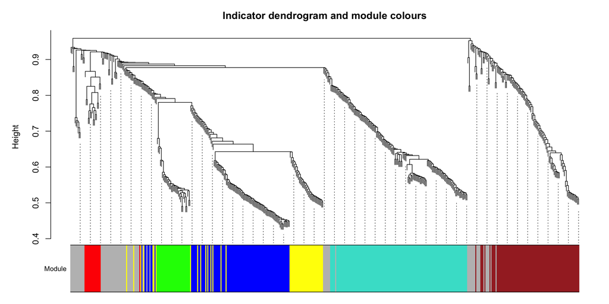

Indicator dendrogram with module colour bar. Grey = unassigned features — these form the independent pool in SF’s split shadow mode.

### 3.3.1 Module membership summary

```r
mod_tbl <- as.data.frame(table(Module = net$colors))
mod_tbl$Independent <- mod_tbl$Module == "grey"
mod_tbl <- mod_tbl[order(mod_tbl$Freq, decreasing = TRUE), ]
knitr::kable(mod_tbl, row.names = FALSE,
             caption = "WGCNA module sizes (grey = independent pool).")
```

WGCNA module sizes (grey = independent pool).

| Module | Freq | Independent |
| --- | --- | --- |
| turquoise | 134 | FALSE |
| blue | 97 | FALSE |
| brown | 91 | FALSE |
| grey | 80 | TRUE |
| yellow | 49 | FALSE |
| green | 33 | FALSE |
| red | 17 | FALSE |

Grey-labelled indicators are **unassigned by WGCNA** and treated as the independent pool. On the rank-transformed network this pool is modest — roughly one indicator in seven — with the remaining ~85% falling into a handful of coherent modules (a macro-economic block, a health/sanitation block, a demographic block, and so on). It is worth appreciating how much the rank transform buys here: on the *raw* indicators a Pearson-based network stranded ~80% of features in grey, purely because their monotonic associations do not register as high linear correlations. Rank-transforming before building the network turns the same data into a well-populated module structure without discarding a single indicator.

The grey pool that remains is exactly the regime SF’s split-shadow machinery is designed for: modular indicators are screened *within* their blocks (controlling for the redundancy inside each bundle), while the independent pool is judged against its own permuted shadows.

### 3.3.2 Eigengene-based connectivity (kME)

Module eigengenes summarise each module’s profile as a single representative vector. Correlating every indicator with each module eigengene gives its **module membership** ($k_{ME}$) — a continuous measure of how central an indicator is to that module, independent of where the dendrogram was cut.

```r
MEs <- net$MEs
kME <- as.data.frame(signedKME(wdi_Xnet, MEs, outputColumnName = "kME"))

gene_kME <- vapply(seq_along(net$colors), function(i) {
  col <- paste0("kME", net$colors[i])
  if (col %in% colnames(kME)) kME[i, col] else NA_real_
}, numeric(1))
```

### 3.3.3 Hub indicators

Intramodular **hub indicators** are the features most strongly correlated with their module’s eigengene ($k_{ME}$ near 1) — the ones that best represent their module’s shared variation.

```r
hub_df <- data.frame(
  indicator = colnames(wdi_X),
  label     = wdi_labels[colnames(wdi_X)],
  module    = net$colors,
  kME       = gene_kME,
  stringsAsFactors = FALSE
)
hub_df <- hub_df[hub_df$module != "grey" & !is.na(hub_df$kME), ]

top_hubs <- hub_df[order(-hub_df$kME), ][seq_len(min(20L, nrow(hub_df))), ]
top_hubs_disp <- top_hubs[, c("label", "module", "kME")]
knitr::kable(top_hubs_disp, row.names = FALSE,
             caption = "Top 20 intramodular hub indicators by kME.")
```

Top 20 intramodular hub indicators by kME.

[output not shown]

```r
library(ggplot2)

p_hub <- ggplot(top_hubs, aes(x = reorder(label, kME), y = kME, colour = module)) +
  geom_segment(aes(xend = label, y = 0, yend = kME), linewidth = 0.9) +
  geom_point(size = 3) +
  scale_colour_identity(guide = "legend", name = "Module",
                        breaks = unique(top_hubs$module),
                        labels = unique(top_hubs$module)) +
  coord_flip() +
  labs(title    = "Top intramodular hub indicators",
       subtitle = "Ranked by eigengene-based connectivity (kME)",
       x = NULL, y = expression(k[ME])) +
  theme_bw()
p_hub
```

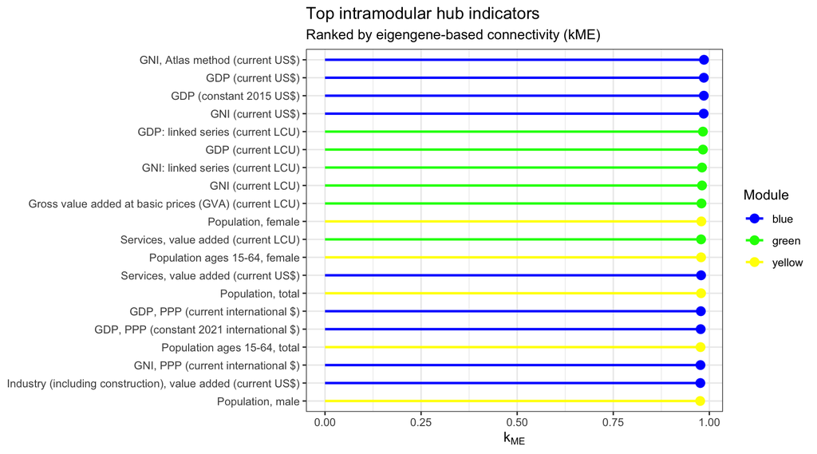

Top 20 intramodular hub indicators ranked by eigengene-based connectivity (kME), coloured by WGCNA module.

### 3.3.4 Final module membership (kME-refined)

Hierarchical clustering can leave borderline indicators mis-assigned at the dendrogram cut. As a final refinement we reassign every indicator to the module whose eigengene it correlates with most strongly (its **maximum-kME module**). This refined membership — not the raw clustering output — is passed to SF.

```r
module_names <- sub("^kME", "", colnames(kME))
best_module  <- module_names[max.col(as.matrix(kME), ties.method = "first")]

module_membership <- best_module
names(module_membership) <- colnames(wdi_X)

# Recode grey (no strong eigengene correlation) → "independent" so SF
# recognises the independent pool
module_membership[module_membership == "grey"] <- "independent"

membership_xtab <- as.data.frame.matrix(
  table(clustering = net$colors, kME_refined = module_membership))
knitr::kable(membership_xtab,
             caption = "Dendrogram clustering vs kME-refined membership (row = clustering colour).")
```

Dendrogram clustering vs kME-refined membership (row = clustering colour).

|  | blue | brown | green | independent | red | turquoise | yellow |
| --- | --- | --- | --- | --- | --- | --- | --- |
| blue | 92 | 0 | 0 | 0 | 0 | 0 | 5 |
| brown | 0 | 88 | 0 | 1 | 0 | 0 | 2 |
| green | 0 | 0 | 33 | 0 | 0 | 0 | 0 |
| grey | 6 | 11 | 9 | 26 | 7 | 12 | 9 |
| red | 0 | 0 | 0 | 0 | 17 | 0 | 0 |
| turquoise | 0 | 0 | 0 | 0 | 0 | 134 | 0 |
| yellow | 0 | 1 | 1 | 0 | 0 | 0 | 47 |

This `module_membership` — computed here on **all** countries — is reused everywhere below: by the single SF run, and by every cross-validation fold and the final refit. WGCNA is **unsupervised** (built only from indicator–indicator correlations in `X`, never seeing `y`), so defining modules on the full matrix does **not** leak the outcome.

# 4 Single SF Run

We fit SF once on the full dataset using the module membership derived above and the **Python backend**, which provides exact TreeSHAP values plus an interaction matrix and is much faster than the pure-R fallback. This requires a Python environment with `scikit-learn`, `shap`, and `numpy` (see `?sf_setup`); configure it once per session with `sf_setup()`.

```r
sf_setup()
```

```r
fit <- sf(
  X = wdi_X,
  y = wdi_y,
  module_membership = module_membership,
  backend = "python",
  verbose = 1L,
  seed = 2026
)
```

## 4.1 Stable set

```r
cat("Stable indicators selected:", length(fit$feature_list$feature_name), "\n")
head(sort(fit$stability_freq, decreasing = TRUE), 20)
```

[output not shown]

### 4.1.1 Domain validation

A stable set is only reassuring if it is *the right* set. As an annotation-free check, we compare it against the indicators that simply correlate most strongly with life expectancy on their own:

1. **Rank agreement with a naive baseline** — do SF’s top features by selection importance line up with the indicators that have the largest absolute Pearson correlation with life expectancy? Agreement means SF is recovering the dominant development signal rather than fitting noise.
2. **Recovery of the strongest univariate signal** — of the indicators most correlated with the outcome, how many does the stable set capture?

```r
stable <- fit$feature_list$feature_name

cors <- vapply(wdi_X, function(col) cor(col, wdi_y), numeric(1))

top_imp <- head(fit$final_SHAP$feature_name[order(-fit$final_SHAP$variable_importance)], 15)
top_c   <- names(sort(abs(cors), decreasing = TRUE))[1:15]
cat("Overlap, top-15 SF-importance vs top-15 |cor| indicators:",
    length(intersect(top_imp, top_c)), "/ 15\n")

top_c30 <- names(sort(abs(cors), decreasing = TRUE))[1:30]
cat("Top-30 |cor| indicators recovered in stable set:",
    length(intersect(top_c30, stable)), "/ 30\n")
```

[output not shown]

## 4.2 Stability plot

```r
plot_stability(fit)
```

[figure not shown]

## 4.3 Feature importance

```r
plot_importance(fit, top_n = 20)
```

[figure not shown]

# 5 Model Comparison: Three-Way Split + Cross-Validated Tuning

## 5.1 Design

We compare **six SF variants** formed by two shadow modes × three DML options:

| Variant | Shadow mode | DML |
| --- | --- | --- |
| `split` | split | none |
| `split_dml` | split | standard |
| `split_mdml` | split | marginal |
| `within` | within_module | none |
| `within_dml` | within_module | standard |
| `within_mdml` | within_module | marginal |

We proceed with the following:

0. **Modules from all data.** The WGCNA network / `module_membership` from the section above (built on all countries) is reused throughout.
1. **Vault a test set** (~20%) — held out once, scored once, at the very end.
2. **On the remaining ~80% (train):** 5-fold CV tunes the hyperparameter grid *and* compares the six variants on both performance (mean validation-fold $R^2$) **and** stability (Nogueira $\hat{\Phi}$ of the stable set across folds).
3. **Select one variant** by a pre-specified rule (below), refit every variant on the *full* train set, and report performance on the test set.

Hyperparameters tuned jointly on the validation folds:

[output not shown]

3 combinations per variant; within-variant tuning criterion **mean validation-fold $R^2$**. All other parameters stay at package defaults.

**Selection rule (fixed in advance).** For each variant, hyperparameters are tuned by predictive $R^2$. Variant *selection* then uses the **Nogueira size-corrected stability index** $\hat{\Phi}$: among variants whose $\hat{\Phi}$ falls within one SE of the maximum, we choose the most **parsimonious** (smallest mean stable set size $\bar{k}$). Predictive performance is reported for reference but does not drive variant selection.

## 5.2 Setup

```r
library(caret)
```

```r
VARIANTS <- list(
  split       = list(shadow_mode = "split",         use_dml_residual = FALSE, dml_scope = "indep"),
  split_dml   = list(shadow_mode = "split",         use_dml_residual = TRUE,  dml_scope = "indep"),
  split_mdml  = list(shadow_mode = "split",         use_dml_residual = TRUE,  dml_scope = "all_modules"),
  within      = list(shadow_mode = "within_module", use_dml_residual = FALSE, dml_scope = "indep"),
  within_dml  = list(shadow_mode = "within_module", use_dml_residual = TRUE,  dml_scope = "indep"),
  within_mdml = list(shadow_mode = "within_module", use_dml_residual = TRUE,  dml_scope = "all_modules")
)

GRID <- expand.grid(
  screen_drop = 0.25,
  select_drop = 0.05,
  pi_thr      = c(0.50, 0.60, 0.70),
  stringsAsFactors = FALSE
)

# ── Three-way split ─────────────────────────────────────────────────────────
# Vault ~20% as the held-out test set; the rest is train.
set.seed(2026)
trainval_idx <- as.integer(caret::createDataPartition(
  wdi_y, p = 0.8, list = FALSE))
test_idx     <- setdiff(seq_along(wdi_y), trainval_idx)

X_tv   <- wdi_X[trainval_idx, ]; y_tv   <- wdi_y[trainval_idx]
X_test <- wdi_X[test_idx, ];     y_test <- wdi_y[test_idx]

# Validation role = 5-fold CV *within* train
val_folds <- caret::createFolds(y_tv, k = 5, returnTrain = FALSE)

cat(sprintf("Train: %d  |  Test vault: %d\n", length(y_tv), length(y_test)))
```

## 5.3 Fit-and-evaluate helper

```r
fit_eval <- function(X_tr, y_tr, X_te, y_te, variant, grid_row) {

  sc  <- screen_control(
    drop_fraction = grid_row$screen_drop,
    min_ntree     = 500L
  )
  sl  <- select_control(
    drop_fraction    = grid_row$select_drop,
    pi_thr           = grid_row$pi_thr,
    n_boots          = 25L,
    min_ntree        = 100L,
    shadow_mode      = variant$shadow_mode,
    use_dml_residual = variant$use_dml_residual,
    dml_scope        = variant$dml_scope
  )

  fit <- tryCatch(
    sf(X_tr, y_tr,
       module_membership = module_membership,
       screen_params     = sc,
       select_params     = sl,
       backend           = "python",
       seed              = 42L,
       verbose           = 0L),
    error = function(e) NULL
  )

  stable <- if (!is.null(fit)) fit$feature_list$feature_name else character(0)
  if (length(stable) == 0L)
    return(list(r2 = NA_real_, rmse = NA_real_,
                n_stable = 0L, stable = character(0)))

  rf   <- ranger::ranger(
    y ~ ., num.trees = 300L, seed = 1L,
    data = data.frame(y = y_tr, X_tr[, stable, drop = FALSE])
  )
  pred <- predict(rf, data.frame(X_te[, stable, drop = FALSE]))$predictions

  sse <- sum((pred - y_te)^2)
  sst <- sum((y_te - mean(y_te))^2)

  list(
    r2       = 1 - sse / sst,
    rmse     = sqrt(mean((pred - y_te)^2)),
    n_stable = length(stable),
    stable   = stable
  )
}
```

## 5.4 Smoke test

The full tuning sweep is 6 variants × 3 grid rows × 5 validation folds (all sharing the one global `module_membership`, so no WGCNA re-runs). Before launching, verify that `fit_eval()` runs end-to-end on a couple of grid rows and a single train/test split.

```r
GRID_smoke <- GRID[1:2, ]
print(GRID_smoke)

set.seed(1)
smoke_split <- caret::createFolds(wdi_y, k = 5, returnTrain = FALSE)[[1]]
train_idx <- setdiff(seq_along(wdi_y), smoke_split)
test_idx  <- smoke_split

smoke_results <- lapply(seq_len(nrow(GRID_smoke)), function(g) {
  fit_eval(wdi_X[train_idx, ], wdi_y[train_idx],
           wdi_X[test_idx,  ], wdi_y[test_idx],
           VARIANTS[["split"]], GRID_smoke[g, ])
})

data.frame(
  grid_row = seq_len(nrow(GRID_smoke)),
  r2       = vapply(smoke_results, `[[`, numeric(1), "r2"),
  rmse     = vapply(smoke_results, `[[`, numeric(1), "rmse"),
  n_stable = vapply(smoke_results, `[[`, numeric(1), "n_stable")
)
```

If both rows return a finite `r2` and `n_stable > 0`, `fit_eval()` and `sf()` are wired correctly and it is safe to launch the full `tune` sweep below.

## 5.5 Cross-validated tuning and stability

For each variant we sweep all 3 grid rows across the five validation folds, record each row’s mean validation $R^2$, and lock the best-scoring row. At that locked setting we keep the per-fold stable sets, whose Nogueira $\hat{\Phi}$ is the variant’s **stability**. Nothing here touches the test vault.

```r
jac_fn <- function(a, b)
  length(intersect(a, b)) / max(length(union(a, b)), 1L)

tune_one <- function(vname) {
  variant <- VARIANTS[[vname]]

  grid_res <- lapply(seq_len(nrow(GRID)), function(g) {
    per_fold <- lapply(seq_along(val_folds), function(fi) {
      vi   <- val_folds[[fi]]
      i_te <- vi; i_tr <- setdiff(seq_along(y_tv), vi)
      r <- fit_eval(X_tv[i_tr, ], y_tv[i_tr],
                    X_tv[i_te, ], y_tv[i_te],
                    variant, GRID[g, ])
      message(sprintf("[%s] g%02d fold%d — r2=%.3f n=%d",
                      vname, g, fi, r$r2, r$n_stable))
      r
    })
    list(
      r2   = mean(vapply(per_fold, `[[`, numeric(1), "r2"), na.rm = TRUE),
      r2s  = vapply(per_fold, `[[`, numeric(1), "r2"),
      sets = lapply(per_fold, `[[`, "stable")
    )
  })

  best_g <- which.max(vapply(grid_res, `[[`, numeric(1), "r2"))
  best   <- grid_res[[best_g]]

  jac <- mean(combn(length(best$sets), 2,
                    function(i) jac_fn(best$sets[[i[1]]], best$sets[[i[2]]]),
                    simplify = TRUE))

  message(sprintf(">>> [%s] DONE — best g%02d cv_r2=%.3f jaccard=%.3f",
                  vname, best_g, best$r2, jac))

  list(
    variant  = vname,
    best_row = GRID[best_g, ],
    cv_r2    = best$r2,
    cv_r2s   = best$r2s,
    jaccard  = jac,
    sets     = best$sets
  )
}

tune <- lapply(names(VARIANTS), tune_one)
names(tune) <- names(VARIANTS)
```

## 5.6 Results

### 5.6.1 Variant selection

For each variant, hyperparameters were tuned by predictive $R^2$. Variant selection itself uses the **Nogueira size-corrected stability index** $\hat{\Phi}$ (Nogueira, Sechidis & Brown, 2018), which corrects the inflation that raw Jaccard exhibits when comparing variants with different stable-set sizes. Among variants whose $\hat{\Phi}$ falls within one SE of the maximum, we select the most **parsimonious** (smallest $\bar{k}$).

```r
# ── Nogueira Φ̂ helpers ───────────────────────────────────────────────────────
.phi_hat <- function(sets, d) {
  M     <- length(sets)
  k_bar <- mean(sapply(sets, length))
  if (k_bar == 0 || k_bar >= d) return(NA_real_)
  pairs <- combn(M, 2, simplify = FALSE)
  sym_d <- sapply(pairs, function(idx) {
    a <- sets[[idx[1]]]; b <- sets[[idx[2]]]
    length(a) + length(b) - 2L * length(intersect(a, b))
  })
  v_obs  <- mean(sym_d) / d
  v_null <- 2 * k_bar * (d - k_bar) / d^2
  1 - v_obs / v_null
}

.phi_se <- function(sets, d) {
  M     <- length(sets)
  k_bar <- mean(sapply(sets, length))
  if (k_bar == 0 || k_bar >= d) return(NA_real_)
  v_null <- 2 * k_bar * (d - k_bar) / d^2
  pairs  <- combn(M, 2, simplify = FALSE)
  v_ij   <- sapply(pairs, function(idx) {
    a <- sets[[idx[1]]]; b <- sets[[idx[2]]]
    (length(a) + length(b) - 2L * length(intersect(a, b))) / d
  })
  sd(v_ij) / (sqrt(length(v_ij)) * v_null)
}

d_total <- ncol(wdi_X)

summary_tbl <- do.call(rbind, lapply(tune, function(t) {
  phi    <- .phi_hat(t$sets, d_total)
  phi_se <- .phi_se(t$sets, d_total)
  k_bar  <- mean(sapply(t$sets, length))
  data.frame(
    Variant        = t$variant,
    CV_R2          = round(t$cv_r2, 3),
    CV_R2_SE       = round(sd(t$cv_r2s, na.rm = TRUE) /
                             sqrt(sum(!is.na(t$cv_r2s))), 3),
    Jaccard        = round(t$jaccard, 3),
    Phi            = round(phi, 3),
    Phi_SE         = round(phi_se, 3),
    k_bar          = round(k_bar, 1),
    `Best pi_thr`  = t$best_row$pi_thr,
    check.names = FALSE, row.names = NULL
  )
}))

# 1-SE rule on Φ̂; parsimony tiebreaker (smallest k̄)
top     <- which.max(summary_tbl$Phi)
cutoff  <- summary_tbl$Phi[top] - summary_tbl$Phi_SE[top]
in_band <- summary_tbl[summary_tbl$Phi >= cutoff, ]
best_v  <- in_band$Variant[which.min(in_band$k_bar)]

knitr::kable(summary_tbl, align = "lccccccc",
             caption = "Validation-fold performance and Nogueira stability (Φ̂) per variant.")
cat("Selected variant (1-SE on Φ̂, parsimony tiebreak):", best_v, "\n")
```

Validation-fold performance and Nogueira stability (Φ̂) per variant.

|  | Variant | CV_R2 | CV_R2_SE | Jaccard | Phi | Phi_SE | k_bar | Best pi_thr |
| --- | --- | --- | --- | --- | --- | --- | --- | --- |
| split | split | 0.850 | 0.017 | 0.731 | 0.790 | 0.010 | 129.0 | 0.5 |
| split_dml | split_dml | 0.850 | 0.017 | 0.731 | 0.790 | 0.010 | 129.0 | 0.5 |
| split_mdml | split_mdml | 0.850 | 0.017 | 0.731 | 0.790 | 0.010 | 129.0 | 0.5 |
| within | within | 0.848 | 0.017 | 0.714 | 0.758 | 0.007 | 155.4 | 0.6 |
| within_dml | within_dml | 0.848 | 0.017 | 0.714 | 0.758 | 0.007 | 155.4 | 0.6 |
| within_mdml | within_mdml | 0.637 | 0.059 | 0.117 | 0.214 | 0.062 | 3.2 | 0.5 |

### 5.6.2 Pairwise variant comparison

The five validation folds give five paired $R^2$ values per variant. We test all 15 pairs with a paired Wilcoxon test and apply Benjamini-Hochberg correction.

```r
pairs <- combn(names(VARIANTS), 2, simplify = FALSE)

pw <- do.call(rbind, lapply(pairs, function(p) {
  a <- tune[[p[1]]]$cv_r2s
  b <- tune[[p[2]]]$cv_r2s
  wt <- wilcox.test(a, b, paired = TRUE, exact = FALSE)
  data.frame(`Method A` = p[1], `Method B` = p[2],
             `ΔR2`      = round(mean(a - b, na.rm = TRUE), 3),
             `p-value`  = round(wt$p.value, 4),
             check.names = FALSE)
}))
pw$`p-adj (BH)` <- round(p.adjust(pw$`p-value`, method = "BH"), 4)
knitr::kable(pw, caption = "Pairwise Wilcoxon tests on validation-fold R².")
```

Pairwise Wilcoxon tests on validation-fold R².

| Method A | Method B | ΔR2 | p-value | p-adj (BH) |
| --- | --- | --- | --- | --- |
| split | split_dml | 0.000 | NaN | NaN |
| split | split_mdml | 0.000 | NaN | NaN |
| split | within | 0.002 | 0.7874 | 0.7874 |
| split | within_dml | 0.002 | 0.7874 | 0.7874 |
| split | within_mdml | 0.213 | 0.0591 | 0.1300 |
| split_dml | split_mdml | 0.000 | NaN | NaN |
| split_dml | within | 0.002 | 0.7874 | 0.7874 |
| split_dml | within_dml | 0.002 | 0.7874 | 0.7874 |
| split_dml | within_mdml | 0.213 | 0.0591 | 0.1300 |
| split_mdml | within | 0.002 | 0.7874 | 0.7874 |
| split_mdml | within_dml | 0.002 | 0.7874 | 0.7874 |
| split_mdml | within_mdml | 0.213 | 0.0591 | 0.1300 |
| within | within_dml | 0.000 | NaN | NaN |
| within | within_mdml | 0.211 | 0.0591 | 0.1300 |
| within_dml | within_mdml | 0.211 | 0.0591 | 0.1300 |

### 5.6.3 Nogueira stability

```r
library(ggplot2)

phi_df <- data.frame(
  Variant = summary_tbl$Variant,
  Phi     = summary_tbl$Phi,
  Phi_SE  = summary_tbl$Phi_SE
)

ggplot(phi_df, aes(x = reorder(Variant, Phi), y = Phi)) +
  geom_col(fill = "#1F77B4", width = 0.6) +
  geom_errorbar(aes(ymin = Phi - Phi_SE, ymax = Phi + Phi_SE),
                width = 0.25, colour = "grey30") +
  geom_hline(yintercept = 0, linetype = "dashed", colour = "grey40") +
  coord_flip() +
  labs(title    = "Nogueira size-corrected stability per variant",
       subtitle = "Error bars = ±1 SE  |  Dashed line = random-selection null (Φ̂ = 0)",
       x = NULL, y = expression(hat(Phi))) +
  theme_bw()
```

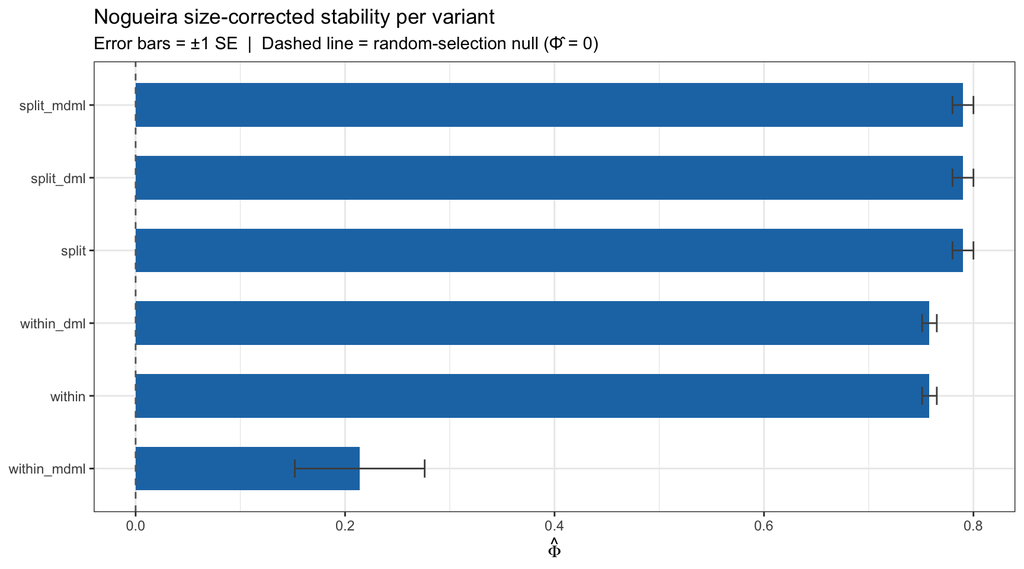

Nogueira size-corrected stability index (Φ̂) per variant with ±1 SE error bars.

### 5.6.4 Final models and held-out test evaluation

We refit **every** variant on the full train+validation set at its locked hyperparameters, then score each on the vaulted test set — the single time the test data is touched. Each `final_models[[v]]$fit` is a complete `shapleyforest` object available for further exploration.

```r
final_models <- lapply(names(VARIANTS), function(vname) {
  variant <- VARIANTS[[vname]]
  row     <- tune[[vname]]$best_row

  sc <- screen_control(
    drop_fraction = row$screen_drop,
    min_ntree     = 500L
  )
  sl <- select_control(
    drop_fraction    = row$select_drop,
    pi_thr           = row$pi_thr,
    n_boots          = 25L,
    min_ntree        = 500L,
    shadow_mode      = variant$shadow_mode,
    use_dml_residual = variant$use_dml_residual,
    dml_scope        = variant$dml_scope
  )

  set.seed(42)
  fit <- sf(X_tv, y_tv,
            module_membership = module_membership,
            screen_params     = sc,
            select_params     = sl,
            backend           = "python",
            seed              = 42L,
            verbose           = 0L)

  stable <- fit$feature_list$feature_name
  rf <- ranger::ranger(
    y ~ ., num.trees = 300L, seed = 1L,
    data = data.frame(y = y_tv, X_tv[, stable, drop = FALSE])
  )
  pred <- predict(rf, data.frame(X_test[, stable, drop = FALSE]))$predictions
  sse  <- sum((pred - y_test)^2); sst <- sum((y_test - mean(y_test))^2)

  list(
    fit       = fit,
    test_r2   = 1 - sse / sst,
    test_rmse = sqrt(mean((pred - y_test)^2)),
    n_stable  = length(stable)
  )
})
names(final_models) <- names(VARIANTS)

test_tbl <- data.frame(
  Variant   = names(final_models),
  Test_R2   = round(vapply(final_models, `[[`, numeric(1), "test_r2"),   3),
  Test_RMSE = round(vapply(final_models, `[[`, numeric(1), "test_rmse"), 3),
  n_stable  = vapply(final_models, `[[`, integer(1), "n_stable"),
  Selected  = ifelse(names(final_models) == best_v, "<<", ""),
  row.names = NULL
)
knitr::kable(test_tbl, align = "lcccc",
             caption = "Held-out test-vault performance (selection made on validation only).")
```

Held-out test-vault performance (selection made on validation only).

| Variant | Test_R2 | Test_RMSE | n_stable | Selected |
| --- | --- | --- | --- | --- |
| split | 0.851 | 2.834 | 131 | << |
| split_dml | 0.851 | 2.834 | 131 |  |
| split_mdml | 0.851 | 2.834 | 131 |  |
| within | 0.844 | 2.897 | 178 |  |
| within_dml | 0.844 | 2.897 | 178 |  |
| within_mdml | 0.821 | 3.108 | 5 |  |

The test vault is small (~20% of only 181 countries), so read these numbers as noisy point estimates — the validation-fold distributions and the pairwise Wilcoxon table above remain the stronger basis for *comparing* variants.

### 5.6.5 Predictive value of the stable set

Does the small stable set actually retain the signal, or does selection throw away useful predictors? We compare a random forest trained on **all 501 indicators** against one trained on **only the SF stable set**, both scored on the same held-out test vault with identical RF settings. If the stable set matches (or beats) the full model with a fraction of the features, SF has cut through the redundancy without losing predictive power.

```r
stable_final <- final_models[[best_v]]$fit$feature_list$feature_name

fit_rf_r2 <- function(feats) {
  rf   <- ranger::ranger(y ~ ., num.trees = 300L, seed = 1L,
                         data = data.frame(y = y_tv, X_tv[, feats, drop = FALSE]))
  pred <- predict(rf, data.frame(X_test[, feats, drop = FALSE]))$predictions
  sse  <- sum((pred - y_test)^2); sst <- sum((y_test - mean(y_test))^2)
  c(r2 = 1 - sse / sst, rmse = sqrt(mean((pred - y_test)^2)))
}

m_full   <- fit_rf_r2(colnames(X_tv))
m_stable <- fit_rf_r2(stable_final)

perf_tbl <- data.frame(
  `Feature set` = c(sprintf("Full (%d indicators)", ncol(X_tv)),
                    sprintf("SF stable set (%d)", length(stable_final))),
  n_features    = c(ncol(X_tv), length(stable_final)),
  Test_R2       = round(c(m_full["r2"],   m_stable["r2"]),   3),
  Test_RMSE     = round(c(m_full["rmse"], m_stable["rmse"]), 3),
  check.names   = FALSE, row.names = NULL
)
knitr::kable(perf_tbl, align = "lccc",
             caption = "Held-out test performance: full feature set vs SF stable set.")
```

Held-out test performance: full feature set vs SF stable set.

| Feature set | n_features | Test_R2 | Test_RMSE |
| --- | --- | --- | --- |
| Full (501 indicators) | 501 | 0.842 | 2.922 |
| SF stable set (131) | 131 | 0.851 | 2.834 |

### 5.6.6 Top stable indicators by SHAP

The deployed model’s most influential indicators, ranked by **mean |SHAP|** (average absolute contribution to the life-expectancy prediction across countries), with their WGCNA module, effect **direction**, and cross-fit selection stability. Direction is the sign of the Spearman correlation between each indicator’s value and its SHAP value: **+** promotes higher life expectancy, **−** suppresses it. Indicators whose SHAP–value relationship is non-monotone (|ρ| < 0.1) are flagged *ambiguous* — a single sign would mislead.

```r
best_fit <- final_models[[best_v]]$fit

sh <- best_fit$final_SHAP
sh$score <- if (!is.null(sh$mean_abs_shap)) sh$mean_abs_shap else abs(sh$variable_importance)
sh <- sh[order(-sh$score), ]

shap_tbl <- data.frame(
  Indicator     = unname(wdi_labels[sh$feature_name]),
  Module        = sh$module_membership,
  `Mean |SHAP|` = round(sh$score, 4),
  Direction     = if (!is.null(sh$direction))
                    ifelse(sh$direction_ambiguous, "ambiguous",
                    ifelse(sh$direction > 0, "+ (promotes)", "− (suppresses)"))
                  else NA_character_,
  Stability     = if (!is.null(sh$stability_freq)) round(sh$stability_freq, 3) else NA_real_,
  check.names   = FALSE,
  row.names     = NULL
)[seq_len(min(10L, nrow(sh))), ]

knitr::kable(shap_tbl, align = "lcccc",
             caption = "Top 10 stable indicators by mean |SHAP| (deployed model).")
```

Top 10 stable indicators by mean |SHAP| (deployed model).

| Indicator | Module | Mean \|SHAP\| | Direction | Stability |
| --- | --- | --- | --- | --- |
| UHC service coverage sub-index on infectious diseases | turquoise | 0.4065 | + (promotes) | 1 |
| People using at least basic sanitation services (% of population) | turquoise | 0.3265 | + (promotes) | 1 |
| Access to electricity (% of population) | turquoise | 0.3075 | + (promotes) | 1 |
| Population ages 0-14, male (% of male population) | brown | 0.2351 | − (suppresses) | 1 |
| UHC service coverage index | turquoise | 0.2261 | + (promotes) | 1 |
| Access to electricity, urban (% of urban population) | turquoise | 0.2138 | + (promotes) | 1 |
| Birth rate, crude (per 1,000 people) | brown | 0.2021 | − (suppresses) | 1 |
| People using at least basic sanitation services, urban (% of urban population) | turquoise | 0.1902 | + (promotes) | 1 |
| Population ages 00-04, male (% of male population) | brown | 0.1656 | − (suppresses) | 1 |
| Fixed broadband subscriptions (per 100 people) | turquoise | 0.1570 | + (promotes) | 1 |

### 5.6.7 Directional feature importance

Magnitude alone (mean |SHAP|) does not say *which way* an indicator pushes the prediction — and mean *signed* SHAP is near zero because positive and negative contributions cancel across countries. `plot_signed_importance()` resolves this by taking each bar’s length from mean |SHAP| and its **sign from the value–SHAP Spearman direction**: bars to the right promote life expectancy, to the left suppress it, and greyed bars are direction-ambiguous.

```r
# `labels` annotates the axis with human-readable indicator names
p_signed <- plot_signed_importance(best_fit, top_n = 30, labels = wdi_labels)
```

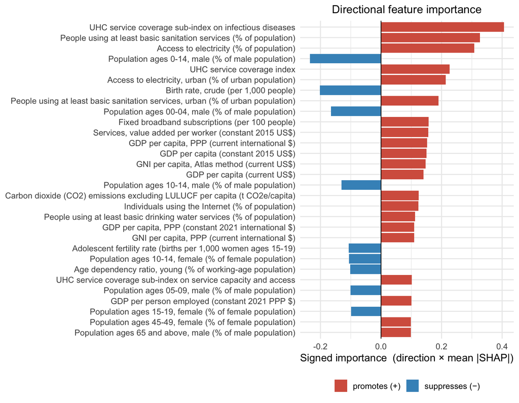

The same information as a table — the top 20 indicators by |signed importance|, with the value–SHAP Spearman correlation ($\rho$) behind each direction call:

```r
sg <- best_fit$final_SHAP
sg <- sg[order(-abs(sg$signed_importance)), ][seq_len(min(20L, nrow(sg))), ]

signed_tbl <- data.frame(
  Indicator           = unname(wdi_labels[sg$feature_name]),
  Module              = sg$module_membership,
  Direction           = ifelse(sg$direction_ambiguous, "ambiguous",
                        ifelse(sg$direction > 0, "+ (promotes)", "− (suppresses)")),
  `rho(value, SHAP)`  = round(sg$dir_corr, 3),
  `Signed importance` = round(sg$signed_importance, 4),
  check.names = FALSE, row.names = NULL
)

knitr::kable(signed_tbl, align = "lcccc",
             caption = "Top 20 indicators by |signed importance| (deployed model).")
```

Top 20 indicators by |signed importance| (deployed model).

[output not shown]

### 5.6.8 Domain validation

As an annotation-free sanity check: do the indicators SF deems stable line up with the indicators that simply correlate most strongly with life expectancy on their own? If the deployed stable set recovers most of the top univariate hits, SF is capturing the dominant development signal while additionally controlling for the block-correlation structure a plain correlation ignores.

```r
stable_final <- best_fit$feature_list$feature_name

# Recovery of the strongest univariate signal
cors  <- vapply(X_tv, function(col) cor(col, y_tv), numeric(1))
top_c <- names(sort(abs(cors), decreasing = TRUE))[1:30]

domain_tbl <- data.frame(
  Metric = c("Selected variant",
             "Deployed stable set size",
             "Top-30 |cor| indicators recovered"),
  Value  = c(best_v,
             as.character(length(stable_final)),
             sprintf("%d / 30", length(intersect(top_c, stable_final)))),
  stringsAsFactors = FALSE
)

knitr::kable(domain_tbl, caption = "Domain validation summary (deployed model).")
```

Domain validation summary (deployed model).

| Metric | Value |
| --- | --- |
| Selected variant | split |
| Deployed stable set size | 131 |
| Top-30 \|cor\| indicators recovered | 29 / 30 |

```r
library(ggplot2)
saveRDS(
  list(
    p_stability  = plot_stability(fit),
    p_importance = plot_importance(fit, top_n = 20),
    p_jaccard    = ggplot(phi_df, aes(x = reorder(Variant, Phi), y = Phi)) +
                     geom_col(fill = "#1F77B4", width = 0.6) +
                     geom_errorbar(aes(ymin = Phi - Phi_SE, ymax = Phi + Phi_SE),
                                   width = 0.25, colour = "grey30") +
                     geom_hline(yintercept = 0, linetype = "dashed", colour = "grey40") +
                     coord_flip() +
                     labs(title    = "Nogueira size-corrected stability per variant",
                          subtitle = "Error bars = ±1 SE  |  Dashed line = random-selection null (Φ̂ = 0)",
                          x = NULL, y = expression(hat(Phi))) +
                     theme_bw(),
    summary_tbl     = summary_tbl,
    pw              = pw,
    test_tbl        = test_tbl,
    perf_tbl        = perf_tbl,
    shap_tbl        = shap_tbl,
    p_signed        = p_signed,
    signed_tbl      = signed_tbl,
    domain_tbl      = domain_tbl,
    mod_tbl         = mod_tbl,
    p_dendro        = p_dendro,
    top_hubs_disp   = top_hubs_disp,
    p_hub           = p_hub,
    membership_xtab = membership_xtab
  ),
  "wdi_results.rds"
)
```

# 6 Reporting Checklist

| Item | Source |
| --- | --- |
| Validation-fold R² + stability per variant | `summary_tbl` |
| Held-out test R² / RMSE per variant | `test_tbl` |
| Selected variant (1-SE on Φ̂) | `best_v` |
| Locked tuned hyperparameters | `summary_tbl` Best * columns |
| Pairwise variant comparison | paired Wilcoxon + BH table |
| Nogueira stability across validation folds | bar chart |
| Soft-threshold power justification | R² + connectivity plots |
| Domain overlap | deployed stable set vs top-correlated indicators |
| Fitted models for plotting | `final_models[[v]]$fit` |